# Data science assignment #1

Kim Dill-McFarland

January 04, 2018

# Instructions

Prior to starting data science modules, you will need to download and install the following software as well as create a GitHub account. You must have administrator privileges on your machine to complete the installs.

# Command line

## Mac and Linux users

The native Mac and Linux command line terminals are sufficient for our purposes in this course. You do not need to download anything additional. You can find this application by searching for ‘terminal’ in your Finder window. Open the Terminal.app and take a screenshot similar to the one below. You may also wish to add a shortcut on your Desktop or Dock.

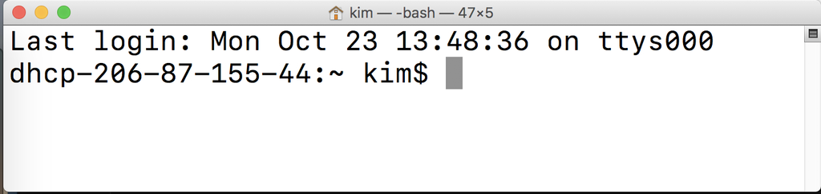

Mac Terminal

## Windows users

The native Windows command line terminal does not work with the same syntax or language at Mac/Linux terminals. So, you will need to install software to create a Linux-based terminal on your Windows machine.

Download [Git](https://git-for-windows.github.io) using the `Git-2.15.1.2-**-bit.exe` where ** is 32 or 64 depending on what matches your operating system (OS). Install the software and open Git Bash (not CMD or GUI). Take a screenshot similar to the one below. You may also wish to add a shortcut on your Desktop or Start menu.

[figure not shown]

Windows Git Bash Terminal